# Happiness Analysis

# Independent two-sample t.test with equal variance :The Independent two-samples t-test is used to compare the mean of two independent groups.

```r
t.test(Happiness_score ~ Region, data = Europe_data, var.equal = TRUE, conf.level = .95)
```

```
##
##  Two Sample t-test
##
## data:  Happiness_score by Region
## t = -4.8355, df = 36, p-value = 2.481e-05
## alternative hypothesis: true difference in means between group Central and Eastern Europe and group Western Europe is not equal to 0
## 95 percent confidence interval:
##  -1.3202593 -0.5400208
## sample estimates:
## mean in group Central and Eastern Europe
##                                 5.984765
##             mean in group Western Europe
##                                 6.914905
```

# STEP 8 : ASSOCIATION BETWEEN VARIABLES

# Checking coorelation between numerical variable.

# Pearson Correlation Matrix

# Creating a data frame for numerical variables only

```r
dataNumerical <- subset(data, select=c("Happiness_score", "GDP", "Social_support", "Life_expectancy", "Freedom", "Generosity", "Corruption", "Dystopia_residual"))
```

# Checking coorelation between numerical variable.

```r
corData <- data.frame(cor(dataNumerical))
corData
```

```
##                   Happiness_score         GDP Social_support Life_expectancy
## Happiness_score        1.00000000  0.78975970     0.75688765       0.7680995
## GDP                    0.78975970  1.00000000     0.78529868       0.8594606
## Social_support         0.75688765  0.78529868     1.00000000       0.7232561
## Life_expectancy        0.76809946  0.85946062     0.72325613       1.0000000
## Freedom                0.60775307  0.43232349     0.48292977       0.4614939
## Generosity            -0.01779928 -0.19928640    -0.11494585      -0.1617503
## Corruption            -0.42114000 -0.34233742    -0.20320698      -0.3643735
## Dystopia_residual      0.49200990 -0.04111918     0.00668051      -0.0234329
##                      Freedom  Generosity  Corruption Dystopia_residual
## Happiness_score    0.6077531 -0.01779928 -0.42114000        0.49200990
## GDP                0.4323235 -0.19928640 -0.34233742       -0.04111918
## Social_support     0.4829298 -0.11494585 -0.20320698        0.00668051
## Life_expectancy    0.4614939 -0.16175028 -0.36437353       -0.02343290
## Freedom            1.0000000  0.16943737 -0.40136297        0.10024227
## Generosity         0.1694374  1.00000000 -0.16396173       -0.02721188
## Corruption        -0.4013630 -0.16396173  1.00000000        0.00447841
## Dystopia_residual  0.1002423 -0.02721188  0.00447841        1.00000000
```

# Coorelation graph

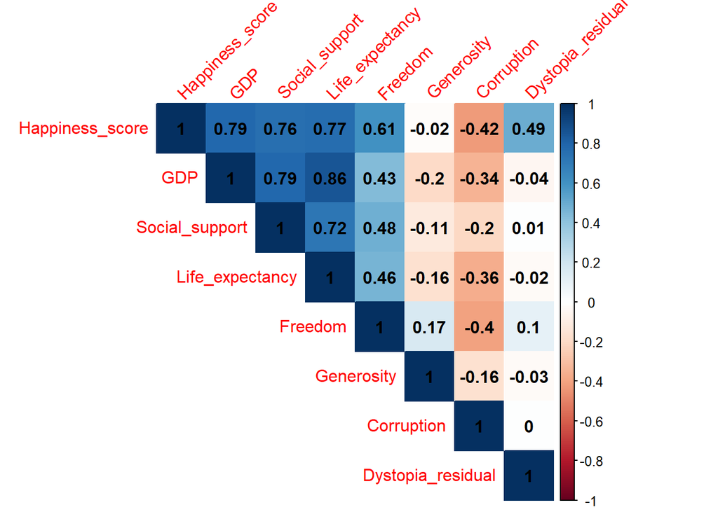

```r
corrplot(cor(dataNumerical %>% select(Happiness_score:Dystopia_residual)),
         method="color", sig.level = 0.01, insig = "blank", addCoef.col = "black",
        tl.srt=45, type="upper"
         )
```

> Thus we observe that GDP, Social Support, Life Expectancy, Freedom and Dystopia_residual have positive correlation with Happiness Score. With GDP being highest. On other hand, corruption has negative correlation with Happiness Score. Thus, if a country is highly corrupt, its happiness score is less. Something interesting here is generosity of people has no major affect on Happiness Score. More accurately, it has a very slight negative effect implying that if people of a country are generous the country is slightly unhappier, score wise.

# Highly coorelated variable

```r
library(lattice)
library(ggplot2)
library(caret)
#Finding highly correlated variables
highly_correlated <- findCorrelation(cor(dataNumerical), cutoff = 0.8)
cat("High correlated variable is",names(corData)[highly_correlated])
```

```
## High correlated variable is GDP
```

# STEP 9 : CREATING TRAINING AND TEST DATASET

# Spliting the data into training and testing data

```r
data1 <- subset(data, select=c("Happiness_score", "GDP", "Social_support", "Life_expectancy", "Freedom", "Generosity", "Corruption", "Dystopia_residual","Region"))

i <- sample(2, size=nrow(data1), replace=TRUE, prob=c(0.8, 0.2))
dataTraining <- data1[i==1,]
dataTest <- data1[i==2,]

cat("Total observations in Training data set is ",nrow(dataTraining))
```

```
## Total observations in Training data set is  119
```

```r
cat("\nTotal observations in Testing data set is ",nrow(dataTest))
```

```
##
## Total observations in Testing data set is  30
```

# STEP 10 : CREATING LINEAR REGRESSION MODELS

# 1. Simple Linear Regression Model

# Constructing a simple linear regression model of Happiness Score by GDP to carry out regression on the data.

```r
Simple_Linear_Model <- lm(Happiness_score~GDP, data=dataTraining)
Simple_Linear_Model_Summary <- summary(Simple_Linear_Model)
Simple_Linear_Model_Summary
```

```
##
## Call:
## lm(formula = Happiness_score ~ GDP, data = dataTraining)
##
## Residuals:
##      Min       1Q   Median       3Q      Max
## -2.31003 -0.45225  0.01712  0.52697  1.32105
##
## Coefficients:
##             Estimate Std. Error t value Pr(>|t|)
## (Intercept) -1.55131    0.52392  -2.961  0.00371 **
## GDP          0.74917    0.05502  13.617  < 2e-16 ***
## ---
## Signif. codes:  0 '***' 0.001 '**' 0.01 '*' 0.05 '.' 0.1 ' ' 1
##
## Residual standard error: 0.6764 on 117 degrees of freedom
## Multiple R-squared:  0.6131, Adjusted R-squared:  0.6098
## F-statistic: 185.4 on 1 and 117 DF,  p-value: < 2.2e-16
```

> Is there a relationship between GDP and Happiness Score? The Null hypothesis here is that there is no relationship between GDP and Happiness Score. We observe that the p-value is <0.05, implying we can reject the null hypotheses and thus conclude Happiness score depends on GDP.

> How strong is the relationship between the predictor and the response? p-value is close to zero, thus relationship is strong

> Is the relationship between the predictor and the response positive or negative? The coefficient is positive and hence there is a positive relationship

# Using Simple Linear Regression Model to predict Happiness Score in dataTest.

```r
y_Simple_Linear_Model_Pred <-predict(object = Simple_Linear_Model, newdata = dataTest)
summary(y_Simple_Linear_Model_Pred)
```

```
##    Min. 1st Qu.  Median    Mean 3rd Qu.    Max.
##   3.909   4.516   5.623   5.445   6.189   7.174
```

# Using Simple Linear Regression Model to predict Confidence Interval on Happiness Score in dataTest.

```r
y_Simple_Linear_Model_Pred_conf <-predict(object = Simple_Linear_Model, newdata = dataTest, interval="confidence")
summary(y_Simple_Linear_Model_Pred_conf)
```

```
##       fit             lwr             upr
##  Min.   :3.909   Min.   :3.642   Min.   :4.175
##  1st Qu.:4.516   1st Qu.:4.323   1st Qu.:4.708
##  Median :5.623   Median :5.500   Median :5.747
##  Mean   :5.445   Mean   :5.267   Mean   :5.623
##  3rd Qu.:6.189   3rd Qu.:6.034   3rd Qu.:6.345
##  Max.   :7.174   Max.   :6.906   Max.   :7.443
```

# Using Simple Linear Regression Model to predict Prediction Interval on Happiness Score in dataTest.

```r
y_Simple_Linear_Model_Pred_pred <-predict(object = Simple_Linear_Model, newdata = dataTest, interval="prediction")
summary(y_Simple_Linear_Model_Pred_pred)
```

```
##       fit             lwr             upr
##  Min.   :3.909   Min.   :2.543   Min.   :5.274
##  1st Qu.:4.516   1st Qu.:3.162   1st Qu.:5.869
##  Median :5.623   Median :4.278   Median :6.969
##  Mean   :5.445   Mean   :4.093   Mean   :6.797
##  3rd Qu.:6.189   3rd Qu.:4.841   3rd Qu.:7.538
##  Max.   :7.174   Max.   :5.808   Max.   :8.540
```

# Predicting Test Set Results for Simple Linear Regression Model

```r
Simple_Linear_Model_Pred_DF <- as.data.frame(cbind(Prediction = y_Simple_Linear_Model_Pred, Actual = dataTest$Happiness_score, Confidence_Interval = y_Simple_Linear_Model_Pred_conf, Prediction_Interval=y_Simple_Linear_Model_Pred_pred))

Simple_Linear_Model_Pred_DF
```

```
##    Prediction Actual      fit      lwr      upr      fit      lwr      upr
## 1    6.777165  7.571 6.777165 6.558433 6.995897 6.777165 5.419892 8.134438
## 2    7.174223  7.324 7.174223 6.905736 7.442710 7.174223 5.808049 8.540397
## 3    6.594368  7.155 6.594368 6.397072 6.791664 6.594368 5.240385 7.948352
## 4    6.356883  6.965 6.356883 6.185270 6.528495 6.356883 5.006403 7.707363
## 5    6.445284  6.602 6.445284 6.264456 6.626113 6.445284 5.093602 7.796967
## 6    6.753191  6.561 6.753191 6.537336 6.969047 6.753191 5.396379 8.110004
## 7    5.834714  6.317 5.834714 5.704295 5.965133 5.834714 4.488848 7.180580
## 8    5.330525  6.309 5.330525 5.204262 5.456788 5.330525 3.985056 6.675995
## 9    6.202555  6.180 6.202555 6.045797 6.359312 6.202555 4.853882 7.551227
## 10   5.780774  6.078 5.780774 5.652785 5.908764 5.780774 4.435141 7.126407
## 11   6.255745  5.929 6.255745 6.094066 6.417425 6.255745 4.906491 7.604999
## 12   6.149364  5.723 6.149364 5.997294 6.301433 6.149364 4.801228 7.497500
## 13   5.225642  5.716 5.225642 5.094983 5.356301 5.225642 3.879753 6.571531
## 14   6.081939  5.477 6.081939 5.935440 6.228438 6.081939 4.734420 7.429458
```

[output cut: 16 more lines]

> The prediction interval is substantially wider than the confidence interval, reflecting the increased uncertainty about Happiness Score in comparison to the average Happiness score.

# Finding RSS, R^2, MAE, MSE, RSE values for simple linear regression model.

```r
library(MLmetrics)
#MAE
Simple_Linear_Model_MAE <- MAE(y_pred = y_Simple_Linear_Model_Pred, y_true = dataTest$Happiness_score)

#MSE
Simple_Linear_Model_MSE <- MSE(y_pred = y_Simple_Linear_Model_Pred, y_true = dataTest$Happiness_score)

#RSS
Simple_Linear_Model_Residual <- resid(Simple_Linear_Model)
Simple_Linear_Model_RSS <- sum(Simple_Linear_Model_Residual^2)

#$R^2$
Simple_Linear_Model_RSquare <- Simple_Linear_Model_Summary$r.squared

#RSE
Simple_Linear_Model_RSE <- Simple_Linear_Model_Summary$sigma

cat("RSS For Simple Linear Regression Model is:",Simple_Linear_Model_RSS)
```

```
## RSS For Simple Linear Regression Model is: 53.52606
```

```r
cat("\nR Squared For Simple Linear Regression Model is:",Simple_Linear_Model_RSquare)
```

```
##
## R Squared For Simple Linear Regression Model is: 0.6131147
```

```r
cat("\nMAE For Simple Linear Regression Model is:",Simple_Linear_Model_MAE)
```

```
##
## MAE For Simple Linear Regression Model is: 0.529038
```

```r
cat("\nMSE For Simple Linear Regression Model is:",Simple_Linear_Model_MSE)
```

```
##
## MSE For Simple Linear Regression Model is: 0.3602327
```

```r
cat("\nRSE For Simple Linear Regression Model is:",Simple_Linear_Model_RSE)
```

```
##
## RSE For Simple Linear Regression Model is: 0.6763784
```

> Mean Absolute Error is the mean of summation of absolute value of actual minus predicted response. Mean Square Error is the mean of summation of square of the actual minus predicted response value. Residual Sum of Square is the summation of square of the actual minus predicted response value. The minimum the above three value, the better the model.

> Residual Standard Error is a measure of lack of fit of the model to the data. If predicted value for one or more observations is far from actual value then RSE will be large indicating a model that does not fit the data well. What constitutes a good RSE is not well defined.

> R2 lies between zero and 1. Higher the value, the better. But the decision is practically made on the application.

# Diagnostic plot for Simple Linear Regression Model

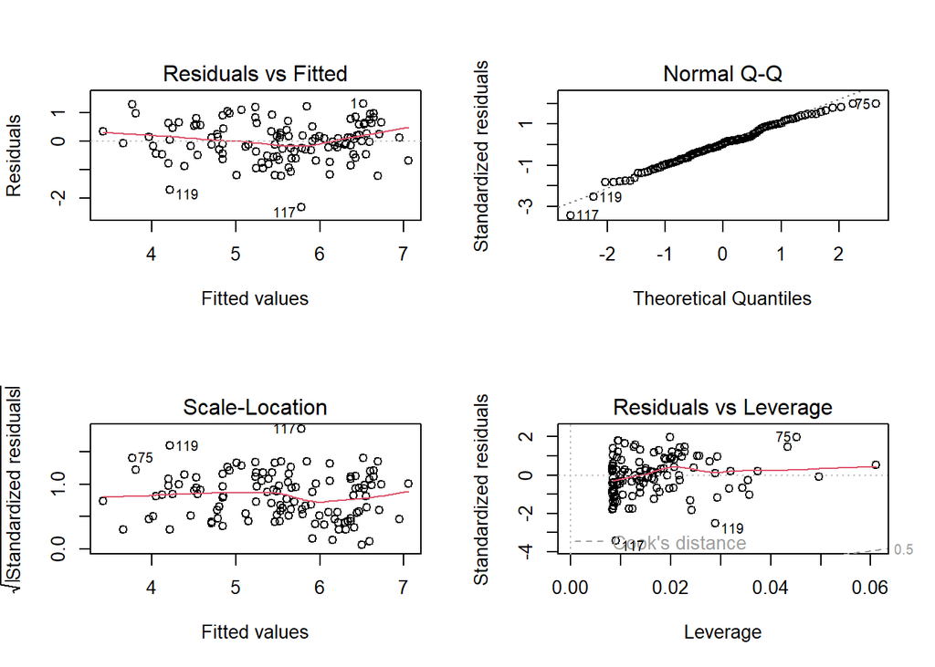

```r
par(mfrow=c(2,2))
plot(Simple_Linear_Model)
```

# 2. Multiple Linear Regression Model

# Constructing a multiple linear regression model of Happiness Score by all features to carry out regression on the data.

```r
Multiple_Regression_Model <- lm(Happiness_score~. , data=dataTraining)
Multiple_Regression_Model_Summary <- summary(Multiple_Regression_Model)
Multiple_Regression_Model_Summary
```

```
##
## Call:
## lm(formula = Happiness_score ~ ., data = dataTraining)
##
## Residuals:
##        Min         1Q     Median         3Q        Max
## -2.266e-03 -5.655e-04 -7.823e-05  5.482e-04  2.001e-03
##
## Coefficients:
##                                            Estimate Std. Error   t value
## (Intercept)                              -4.564e+00  2.028e-03 -2250.054
## GDP                                       3.492e-01  1.877e-04  1860.805
## Social_support                            2.253e+00  1.354e-03  1663.333
## Life_expectancy                           3.152e-02  3.042e-05  1035.948
## Freedom                                   1.217e+00  9.896e-04  1229.956
## Generosity                                6.521e-01  6.509e-04  1001.855
## Corruption                               -6.390e-01  6.107e-04 -1046.249
## Dystopia_residual                         1.000e+00  1.710e-04  5849.436
## RegionCommonwealth of Independent States -1.951e-04  4.143e-04    -0.471
## RegionEast Asia                          -6.809e-04  4.481e-04    -1.519
## RegionLatin America and Caribbean        -4.378e-04  3.434e-04    -1.275
## RegionMiddle East and North Africa       -6.877e-04  3.491e-04    -1.970
## RegionNorth America and ANZ              -8.471e-04  5.658e-04    -1.497
## RegionSouth Asia                         -5.826e-04  5.478e-04    -1.064
## RegionSoutheast Asia                     -8.178e-04  4.569e-04    -1.790
## RegionSub-Saharan Africa                 -1.488e-04  4.441e-04    -0.335
## RegionWestern Europe                     -4.236e-04  3.998e-04    -1.059
##                                          Pr(>|t|)
## (Intercept)                                <2e-16 ***
## GDP                                        <2e-16 ***
## Social_support                             <2e-16 ***
## Life_expectancy                            <2e-16 ***
## Freedom                                    <2e-16 ***
## Generosity                                 <2e-16 ***
## Corruption                                 <2e-16 ***
## Dystopia_residual                          <2e-16 ***
## RegionCommonwealth of Independent States   0.6387
## RegionEast Asia                            0.1317
## RegionLatin America and Caribbean          0.2053
## RegionMiddle East and North Africa         0.0516 .
## RegionNorth America and ANZ                0.1374
## RegionSouth Asia                           0.2900
## RegionSoutheast Asia                       0.0765 .
## RegionSub-Saharan Africa                   0.7383
## RegionWestern Europe                       0.2920
## ---
## Signif. codes:  0 '***' 0.001 '**' 0.01 '*' 0.05 '.' 0.1 ' ' 1
##
## Residual standard error: 0.0008723 on 102 degrees of freedom
## Multiple R-squared:      1,  Adjusted R-squared:      1
## F-statistic: 1.136e+07 on 16 and 102 DF,  p-value: < 2.2e-16
```

> Is there a relationship between the predictors and the response? - Null Hypothesis: There is no relationship between predictors and response Alternative Hypothesis: Response is dependent on atleast one predictor We see that the F-statistic is highly greater than 1 and hence we reject the null hypothesis. Thus there is a relationship between atleast one predictor and the response.

> Which predictors appear to have a statistically significant relationship to the response? All the predictors except Region appear to have a statistically signiticant relationship to the response.

> What does one unit increase in corruption imply? A one unit increase in corruption implies that Happiness Score would reduce by 0.6388.

```r
library(car)
car::vif(Multiple_Regression_Model)
```

```
##                        GVIF Df GVIF^(1/(2*Df))
## GDP                6.996906  1        2.645167
## Social_support     4.113836  1        2.028259
## Life_expectancy    6.671314  1        2.582889
## Freedom            2.014488  1        1.419327
## Generosity         1.474958  1        1.214479
## Corruption         1.951564  1        1.396984
## Dystopia_residual  1.356361  1        1.164629
## Region            18.808947  9        1.177058
```

# Now we will again construct multiple linear regression without Region variable.

```r
Multiple_Regression_Model <- lm(Happiness_score~. -Region , data=dataTraining)
Multiple_Regression_Model_Summary <- summary(Multiple_Regression_Model)
Multiple_Regression_Model_Summary
```

```
##
## Call:
## lm(formula = Happiness_score ~ . - Region, data = dataTraining)
##
## Residuals:
##        Min         1Q     Median         3Q        Max
## -0.0020912 -0.0006345 -0.0001140  0.0006069  0.0021282
##
## Coefficients:
##                     Estimate Std. Error t value Pr(>|t|)
## (Intercept)       -4.564e+00  1.201e-03   -3799   <2e-16 ***
## GDP                3.492e-01  1.684e-04    2074   <2e-16 ***
## Social_support     2.253e+00  1.191e-03    1892   <2e-16 ***
## Life_expectancy    3.150e-02  2.378e-05    1325   <2e-16 ***
## Freedom            1.217e+00  8.868e-04    1373   <2e-16 ***
## Generosity         6.518e-01  5.778e-04    1128   <2e-16 ***
## Corruption        -6.389e-01  5.147e-04   -1241   <2e-16 ***
## Dystopia_residual  1.000e+00  1.498e-04    6677   <2e-16 ***
## ---
## Signif. codes:  0 '***' 0.001 '**' 0.01 '*' 0.05 '.' 0.1 ' ' 1
##
## Residual standard error: 0.0008709 on 111 degrees of freedom
## Multiple R-squared:      1,  Adjusted R-squared:      1
## F-statistic: 2.606e+07 on 7 and 111 DF,  p-value: < 2.2e-16
```

# Using Multiple Linear Regression Model to predict Happiness Score in dataTest.

```r
y_Multiple_Regression_Model_Pred <-predict(object = Multiple_Regression_Model, newdata = dataTest)
summary(y_Multiple_Regression_Model_Pred)
```

```
##    Min. 1st Qu.  Median    Mean 3rd Qu.    Max.
##   3.145   4.932   5.439   5.534   6.278   7.572
```

# Using Multiple Linear Regression Model to predict Confidence Interval on Happiness Score in dataTest.

```r
y_Multiple_Regression_Model_Pred_conf <-predict(object = Multiple_Regression_Model, newdata = dataTest, interval="confidence")
summary(y_Multiple_Regression_Model_Pred_conf)
```

```
##       fit             lwr             upr
##  Min.   :3.145   Min.   :3.144   Min.   :3.145
##  1st Qu.:4.932   1st Qu.:4.931   1st Qu.:4.932
##  Median :5.439   Median :5.438   Median :5.440
##  Mean   :5.534   Mean   :5.534   Mean   :5.534
##  3rd Qu.:6.278   3rd Qu.:6.278   3rd Qu.:6.279
##  Max.   :7.572   Max.   :7.572   Max.   :7.573
```

# Using Multiple Regression Model to predict Prediction Interval on Happiness Score in dataTest.

```r
y_Multiple_Regression_Model_Pred_pred <-predict(object = Multiple_Regression_Model, newdata = dataTest, interval="prediction")
summary(y_Multiple_Regression_Model_Pred_pred)
```

```
##       fit             lwr             upr
##  Min.   :3.145   Min.   :3.143   Min.   :3.146
##  1st Qu.:4.932   1st Qu.:4.930   1st Qu.:4.933
##  Median :5.439   Median :5.437   Median :5.441
##  Mean   :5.534   Mean   :5.532   Mean   :5.536
##  3rd Qu.:6.278   3rd Qu.:6.276   3rd Qu.:6.280
##  Max.   :7.572   Max.   :7.571   Max.   :7.574
```

# Predicting Test Set Results for Multiple Linear Regression Model

```r
Multiple_Regression_Model_Pred_DF <- as.data.frame(cbind(Prediction = y_Multiple_Regression_Model_Pred, Actual = dataTest$Happiness_score, Confidence_Interval = y_Multiple_Regression_Model_Pred_conf, Prediction_Interval=y_Multiple_Regression_Model_Pred_pred))

Multiple_Regression_Model_Pred_DF
```

```
##    Prediction Actual      fit      lwr      upr      fit      lwr      upr
## 1    7.572420  7.571 7.572420 7.571977 7.572862 7.572420 7.570638 7.574201
## 2    7.325034  7.324 7.325034 7.324541 7.325528 7.325034 7.323239 7.326829
## 3    7.154474  7.155 7.154474 7.154135 7.154812 7.154474 7.152715 7.156232
## 4    6.965541  6.965 6.965541 6.965137 6.965946 6.965541 6.963769 6.967314
## 5    6.602081  6.602 6.602081 6.601766 6.602396 6.602081 6.600327 6.603836
## 6    6.558768  6.561 6.558768 6.558251 6.559285 6.558768 6.556967 6.560570
## 7    6.316841  6.317 6.316841 6.316514 6.317168 6.316841 6.315085 6.318598
## 8    6.311254  6.309 6.311254 6.310819 6.311688 6.311254 6.309474 6.313033
## 9    6.179317  6.180 6.179317 6.178983 6.179651 6.179317 6.177559 6.181075
## 10   6.079282  6.078 6.079282 6.079025 6.079539 6.079282 6.077538 6.081027
## 11   5.928335  5.929 5.928335 5.927872 5.928797 5.928335 5.926548 5.930121
## 12   5.723483  5.723 5.723483 5.722971 5.723995 5.723483 5.721683 5.725283
## 13   5.717580  5.716 5.717580 5.717278 5.717882 5.717580 5.715828 5.719332
## 14   5.477363  5.477 5.477363 5.477041 5.477685 5.477363 5.475607 5.479118
```

[output cut: 16 more lines]

> The prediction interval is substantially wider than the confidence interval, reflecting the increased uncertainty about Happiness Score in comparison to the average Happiness score.

# Finding RSS, R^2, MAE and MSE values for Multiple linear regression model.

```r
library(MLmetrics)

#MAE
Multiple_Regression_Model_MAE <- MAE(y_pred = y_Multiple_Regression_Model_Pred, y_true = dataTest$Happiness_score)

#MSE
Multiple_Regression_Model_MSE <- MSE(y_pred = y_Multiple_Regression_Model_Pred, y_true = dataTest$Happiness_score)

#RSS
Multiple_Regression_Model_Residual <- resid(Multiple_Regression_Model)
Multiple_Regression_Model_RSS <- sum(Multiple_Regression_Model_Residual^2)

#$R^2$
Multiple_Regression_Model_RSquare <- Multiple_Regression_Model_Summary$r.squared

#RSE
Multiple_Regression_Model_RSE <- Multiple_Regression_Model_Summary$sigma


cat("RSS For Multiple Linear Regression Model is:",Multiple_Regression_Model_RSS)
```

```
## RSS For Multiple Linear Regression Model is: 8.418921e-05
```

```r
cat("\nR Squared For Multiple Linear Regression Model is:",Multiple_Regression_Model_RSquare)
```

```
##
## R Squared For Multiple Linear Regression Model is: 0.9999994
```

```r
cat("\nMAE For Multiple Linear Regression Model is:",Multiple_Regression_Model_MAE)
```

```
##
## MAE For Multiple Linear Regression Model is: 0.0008054113
```

```r
cat("\nMSE For Multiple Linear Regression Model is:",Multiple_Regression_Model_MSE)
```

```
##
## MSE For Multiple Linear Regression Model is: 9.980804e-07
```

```r
cat("\nRSE For Multiple Linear Regression Model is:",Multiple_Regression_Model_RSE)
```

```
##
## RSE For Multiple Linear Regression Model is: 0.0008708969
```

> The MSE, MAE, RSE are too small. Suggesting a good model or an overfit. Since they were calculated on testing data, we do not think it is overfitting and conclude it is a good model.

# Diagnostic plot for Multiple Linear Regression Model

```r
par(mfrow=c(2,2))
plot(Multiple_Regression_Model)
```

[output not shown]

# 3. Forward Stepwise Subset Selection Linear Regression Model

> Begins with Null Model Fit p simple linear regressions and add to the null model the variable that results in the lowest RSS. Add to that model the variable that results in the lowest RSS amongst all two-variable models. Continue until some stopping rule is satisfied, for example when all remaining variables have a p-value above some threshold.

```r
library(MASS)
# Create a null model
forward_intercept_only <- lm(Happiness_score ~ 1, data=dataTraining)
# Create a full model
forward_all <- lm(Happiness_score~., data=dataTraining)
# perform forward step-wise regression
Forward_Regression_Model <- stepAIC (forward_intercept_only, direction='forward',scope = formula(forward_all))
```

```
## Start:  AIC=19.93
## Happiness_score ~ 1
##
##                     Df Sum of Sq     RSS     AIC
## + GDP                1    84.825  53.526 -91.076
## + Life_expectancy    1    80.166  58.186 -81.143
## + Region             9    86.886  51.465 -79.747
## + Social_support     1    79.178  59.173 -79.141
## + Freedom            1    49.896  88.456 -31.298
## + Dystopia_residual  1    33.285 105.066 -10.820
## + Corruption         1    25.060 113.291  -1.850
## <none>                           138.351  19.930
## + Generosity         1     0.085 138.266  21.857
##
## Step:  AIC=-91.08
## Happiness_score ~ GDP
##
##                     Df Sum of Sq    RSS      AIC
## + Dystopia_residual  1    39.699 13.827 -250.146
## + Freedom            1    13.904 39.623 -124.867
## + Region             9    17.267 36.259 -119.423
## + Social_support     1     6.401 47.125 -104.232
## + Life_expectancy    1     4.053 49.473  -98.447
## + Corruption         1     4.037 49.490  -98.406
## + Generosity         1     2.557 50.970  -94.900
## <none>                           53.526  -91.076
##
## Step:  AIC=-250.15
## Happiness_score ~ GDP + Dystopia_residual
##
##                   Df Sum of Sq     RSS     AIC
## + Freedom          1    7.5323  6.2949 -341.79
## + Social_support   1    4.2612  9.5660 -291.99
## + Generosity       1    3.7636 10.0636 -285.95
## + Region           9    4.9296  8.8976 -284.61
## + Corruption       1    3.4279 10.3993 -282.05
## + Life_expectancy  1    3.3305 10.4967 -280.94
## <none>                         13.8272 -250.15
##
## Step:  AIC=-341.79
```

[output cut: 31 more lines]

```
## Happiness_score ~ GDP + Dystopia_residual + Freedom + Social_support +
##     Corruption + Life_expectancy
##
##              Df Sum of Sq     RSS      AIC
## + Generosity  1   0.96500 0.00008 -1669.23
## + Region      9   0.20134 0.76375  -568.79
## <none>                    0.96508  -558.94
##
## Step:  AIC=-1669.23
## Happiness_score ~ GDP + Dystopia_residual + Freedom + Social_support +
##     Corruption + Life_expectancy + Generosity
##
##          Df  Sum of Sq        RSS     AIC
## <none>                 8.4189e-05 -1669.2
## + Region  9 6.5828e-06 7.7606e-05 -1660.9
```

# Viewing Results of Forward Stepwise Subset Selection Linear Regression Model

```r
# view results of forward stepwise regression
Forward_Regression_Model$anova
```

```
## Stepwise Model Path
## Analysis of Deviance Table
##
## Initial Model:
## Happiness_score ~ 1
##
## Final Model:
## Happiness_score ~ GDP + Dystopia_residual + Freedom + Social_support +
##     Corruption + Life_expectancy + Generosity
##
##
##                  Step Df   Deviance Resid. Df   Resid. Dev         AIC
## 1                                         118 1.383513e+02    19.93000
## 2               + GDP  1 84.8251928       117 5.352606e+01   -91.07562
## 3 + Dystopia_residual  1 39.6988804       116 1.382718e+01  -250.14596
## 4           + Freedom  1  7.5322583       115 6.294925e+00  -341.78619
## 5    + Social_support  1  2.0628842       114 4.232041e+00  -387.03626
## 6        + Corruption  1  1.9891412       113 2.242900e+00  -460.59112
## 7   + Life_expectancy  1  1.2778150       112 9.650846e-01  -558.94489
## 8        + Generosity  1  0.9650005       111 8.418921e-05 -1669.22650
```

# Viewing summary for Forward Stepwise Subset Selection Linear Regression Model

```r
# view final model
Forward_Regression_Model_Summary <- summary(Forward_Regression_Model)
Forward_Regression_Model_Summary
```

```
##
## Call:
## lm(formula = Happiness_score ~ GDP + Dystopia_residual + Freedom +
##     Social_support + Corruption + Life_expectancy + Generosity,
##     data = dataTraining)
##
## Residuals:
##        Min         1Q     Median         3Q        Max
## -0.0020912 -0.0006345 -0.0001140  0.0006069  0.0021282
##
## Coefficients:
##                     Estimate Std. Error t value Pr(>|t|)
## (Intercept)       -4.564e+00  1.201e-03   -3799   <2e-16 ***
## GDP                3.492e-01  1.684e-04    2074   <2e-16 ***
## Dystopia_residual  1.000e+00  1.498e-04    6677   <2e-16 ***
## Freedom            1.217e+00  8.868e-04    1373   <2e-16 ***
## Social_support     2.253e+00  1.191e-03    1892   <2e-16 ***
## Corruption        -6.389e-01  5.147e-04   -1241   <2e-16 ***
## Life_expectancy    3.150e-02  2.378e-05    1325   <2e-16 ***
## Generosity         6.518e-01  5.778e-04    1128   <2e-16 ***
## ---
## Signif. codes:  0 '***' 0.001 '**' 0.01 '*' 0.05 '.' 0.1 ' ' 1
##
## Residual standard error: 0.0008709 on 111 degrees of freedom
## Multiple R-squared:      1,  Adjusted R-squared:      1
## F-statistic: 2.606e+07 on 7 and 111 DF,  p-value: < 2.2e-16
```

# Using Forward Stepwise Subset Selection Linear Regression Model to predict Happiness Score in dataTest.

```r
y_Forward_Regression_Model_Pred <-predict(object = Forward_Regression_Model, newdata = dataTest)
summary(y_Forward_Regression_Model_Pred)
```

```
##    Min. 1st Qu.  Median    Mean 3rd Qu.    Max.
##   3.145   4.932   5.439   5.534   6.278   7.572
```

# Using Forward Stepwise Subset Selection Linear Regression Model to predict Confidence Interval on Happiness Score in dataTest.

```r
y_Forward_Regression_Model_Pred_conf <-predict(object = Forward_Regression_Model, newdata = dataTest, interval="confidence")
summary(y_Forward_Regression_Model_Pred_conf)
```

```
##       fit             lwr             upr
##  Min.   :3.145   Min.   :3.144   Min.   :3.145
##  1st Qu.:4.932   1st Qu.:4.931   1st Qu.:4.932
##  Median :5.439   Median :5.438   Median :5.440
##  Mean   :5.534   Mean   :5.534   Mean   :5.534
##  3rd Qu.:6.278   3rd Qu.:6.278   3rd Qu.:6.279
##  Max.   :7.572   Max.   :7.572   Max.   :7.573
```

# Using Forward Stepwise Subset Selection Linear Regression Model to predict Prediction Interval on Happiness Score in dataTest.

```r
y_Forward_Regression_Model_Pred_pred <-predict(object = Forward_Regression_Model, newdata = dataTest, interval="prediction")
summary(y_Forward_Regression_Model_Pred_pred)
```

```
##       fit             lwr             upr
##  Min.   :3.145   Min.   :3.143   Min.   :3.146
##  1st Qu.:4.932   1st Qu.:4.930   1st Qu.:4.933
##  Median :5.439   Median :5.437   Median :5.441
##  Mean   :5.534   Mean   :5.532   Mean   :5.536
##  3rd Qu.:6.278   3rd Qu.:6.276   3rd Qu.:6.280
##  Max.   :7.572   Max.   :7.571   Max.   :7.574
```

# Predicting Test Set Results for Forward Stepwise Subset Selection Linear Regression Model

```r
Forward_Regression_Model_Pred_DF <- as.data.frame(cbind(Prediction = y_Forward_Regression_Model_Pred, Actual = dataTest$Happiness_score, Confidence_Interval = y_Forward_Regression_Model_Pred_conf, Prediction_Interval=y_Forward_Regression_Model_Pred_pred))

Forward_Regression_Model_Pred_DF
```

```
##    Prediction Actual      fit      lwr      upr      fit      lwr      upr
## 1    7.572420  7.571 7.572420 7.571977 7.572862 7.572420 7.570638 7.574201
## 2    7.325034  7.324 7.325034 7.324541 7.325528 7.325034 7.323239 7.326829
## 3    7.154474  7.155 7.154474 7.154135 7.154812 7.154474 7.152715 7.156232
## 4    6.965541  6.965 6.965541 6.965137 6.965946 6.965541 6.963769 6.967314
## 5    6.602081  6.602 6.602081 6.601766 6.602396 6.602081 6.600327 6.603836
## 6    6.558768  6.561 6.558768 6.558251 6.559285 6.558768 6.556967 6.560570
## 7    6.316841  6.317 6.316841 6.316514 6.317168 6.316841 6.315085 6.318598
## 8    6.311254  6.309 6.311254 6.310819 6.311688 6.311254 6.309474 6.313033
## 9    6.179317  6.180 6.179317 6.178983 6.179651 6.179317 6.177559 6.181075
## 10   6.079282  6.078 6.079282 6.079025 6.079539 6.079282 6.077538 6.081027
## 11   5.928335  5.929 5.928335 5.927872 5.928797 5.928335 5.926548 5.930121
## 12   5.723483  5.723 5.723483 5.722971 5.723995 5.723483 5.721683 5.725283
## 13   5.717580  5.716 5.717580 5.717278 5.717882 5.717580 5.715828 5.719332
## 14   5.477363  5.477 5.477363 5.477041 5.477685 5.477363 5.475607 5.479118
```

[output cut: 16 more lines]

> The prediction interval is substantially wider than the confidence interval, reflecting the increased uncertainty about Happiness Score in comparison to the average Happiness score.

# Finding RSS, R^2, MAE and MSE values for Forward Stepwise Subset Selection Linear Regression Model

```r
library(MLmetrics)

#MAE
Forward_Regression_Model_MAE <- MAE(y_pred = y_Forward_Regression_Model_Pred, y_true = dataTest$Happiness_score)

#MSE
Forward_Regression_Model_MSE <- MSE(y_pred = y_Forward_Regression_Model_Pred, y_true = dataTest$Happiness_score)

#RSS
Forward_Regression_Model_Residual <- resid(Forward_Regression_Model)
Forward_Regression_Model_RSS <- sum(Forward_Regression_Model_Residual^2)

#$R^2$
Forward_Regression_Model_RSquare <- Forward_Regression_Model_Summary$r.squared

#RSE
Forward_Regression_Model_RSE <- Forward_Regression_Model_Summary$sigma

cat("RSS For Forward Stepwise Subset Selection Linear Regression Model is:",Forward_Regression_Model_RSS)
```

```
## RSS For Forward Stepwise Subset Selection Linear Regression Model is: 8.418921e-05
```

```r
cat("\nR Squared For Forward Stepwise Subset Selection Linear Regression Model is:",Forward_Regression_Model_RSquare)
```

```
##
## R Squared For Forward Stepwise Subset Selection Linear Regression Model is: 0.9999994
```

```r
cat("\nMAE For Forward Stepwise Subset Selection Linear Regression Model is:",Forward_Regression_Model_MAE)
```

```
##
## MAE For Forward Stepwise Subset Selection Linear Regression Model is: 0.0008054113
```

```r
cat("\nMSE For Forward Stepwise Subset Selection Linear Regression Model is:",Forward_Regression_Model_MSE)
```

```
##
## MSE For Forward Stepwise Subset Selection Linear Regression Model is: 9.980804e-07
```

```r
cat("\nRSE For Forward Stepwise Subset Selection Linear Regression Model is:",Forward_Regression_Model_RSE)
```

```
##
## RSE For Forward Stepwise Subset Selection Linear Regression Model is: 0.0008708969
```

# Diagnostic plot for Forward Stepwise Subset Selection Linear Regression Model

```r
par(mfrow=c(2,2))
plot(Forward_Regression_Model)
```

[output not shown]

# 4. Backward Stepwise Subset Selection Linear Regression Model

> Start with all variables in the model. Remove the variable with the largest p-value — that is, the variable that is the least statistically significant. The new (p−1) variable model is fit, and the variable with the largest p-value is removed. Continue until a stopping rule is reached.

```r
# Create a full model
backward_all <- lm(Happiness_score~., data=dataTraining)
# perform Backward step-wise regression
Backward_Regression_Model <- stepAIC (backward_all, direction='backward')
```

```
## Start:  AIC=-1660.92
## Happiness_score ~ GDP + Social_support + Life_expectancy + Freedom +
##     Generosity + Corruption + Dystopia_residual + Region
##
##                     Df Sum of Sq     RSS      AIC
## - Region             9    0.0000  0.0001 -1669.23
## <none>                            0.0001 -1660.92
## - Generosity         1    0.7637  0.7637  -568.79
## - Life_expectancy    1    0.8165  0.8166  -560.82
## - Corruption         1    0.8329  0.8329  -558.47
## - Freedom            1    1.1510  1.1511  -519.97
## - Social_support     1    2.1050  2.1051  -448.14
## - GDP                1    2.6345  2.6346  -421.44
## - Dystopia_residual  1   26.0331 26.0331  -148.85
##
## Step:  AIC=-1669.23
## Happiness_score ~ GDP + Social_support + Life_expectancy + Freedom +
##     Generosity + Corruption + Dystopia_residual
##
##                     Df Sum of Sq    RSS      AIC
## <none>                            0.000 -1669.23
## - Generosity         1     0.965  0.965  -558.94
## - Corruption         1     1.168  1.169  -536.18
## - Life_expectancy    1     1.331  1.331  -520.65
## - Freedom            1     1.429  1.429  -512.24
## - Social_support     1     2.715  2.716  -435.83
## - GDP                1     3.262  3.262  -414.02
## - Dystopia_residual  1    33.819 33.819  -135.71
```

# Viewing Results of Backward Stepwise Subset Selection Linear Regression Model

```r
# view results of backward stepwise regression
Backward_Regression_Model$anova
```

```
## Stepwise Model Path
## Analysis of Deviance Table
##
## Initial Model:
## Happiness_score ~ GDP + Social_support + Life_expectancy + Freedom +
##     Generosity + Corruption + Dystopia_residual + Region
##
## Final Model:
## Happiness_score ~ GDP + Social_support + Life_expectancy + Freedom +
##     Generosity + Corruption + Dystopia_residual
##
##
##       Step Df     Deviance Resid. Df   Resid. Dev       AIC
## 1                                102 7.760641e-05 -1660.915
## 2 - Region  9 6.582807e-06       111 8.418921e-05 -1669.227
```

# Viewing summary for Backward Stepwise Subset Selection Linear Regression Model

```r
# view final model
Backward_Regression_Model_Summary <- summary(Backward_Regression_Model)
Backward_Regression_Model_Summary
```

```
##
## Call:
## lm(formula = Happiness_score ~ GDP + Social_support + Life_expectancy +
##     Freedom + Generosity + Corruption + Dystopia_residual, data = dataTraining)
##
## Residuals:
##        Min         1Q     Median         3Q        Max
## -0.0020912 -0.0006345 -0.0001140  0.0006069  0.0021282
##
## Coefficients:
##                     Estimate Std. Error t value Pr(>|t|)
## (Intercept)       -4.564e+00  1.201e-03   -3799   <2e-16 ***
## GDP                3.492e-01  1.684e-04    2074   <2e-16 ***
## Social_support     2.253e+00  1.191e-03    1892   <2e-16 ***
## Life_expectancy    3.150e-02  2.378e-05    1325   <2e-16 ***
## Freedom            1.217e+00  8.868e-04    1373   <2e-16 ***
## Generosity         6.518e-01  5.778e-04    1128   <2e-16 ***
## Corruption        -6.389e-01  5.147e-04   -1241   <2e-16 ***
## Dystopia_residual  1.000e+00  1.498e-04    6677   <2e-16 ***
## ---
## Signif. codes:  0 '***' 0.001 '**' 0.01 '*' 0.05 '.' 0.1 ' ' 1
##
## Residual standard error: 0.0008709 on 111 degrees of freedom
## Multiple R-squared:      1,  Adjusted R-squared:      1
## F-statistic: 2.606e+07 on 7 and 111 DF,  p-value: < 2.2e-16
```

# Using Backward Stepwise Subset Selection Linear Regression Model to predict Happiness Score in dataTest.

```r
y_Backward_Regression_Model_Pred <-predict(object = Backward_Regression_Model, newdata = dataTest)
summary(y_Backward_Regression_Model_Pred)
```

```
##    Min. 1st Qu.  Median    Mean 3rd Qu.    Max.
##   3.145   4.932   5.439   5.534   6.278   7.572
```

# Using Backward Stepwise Subset Selection Linear Regression Model to predict Confidence Interval on Happiness Score in dataTest.

```r
y_Backward_Regression_Model_Pred_conf <-predict(object = Backward_Regression_Model, newdata = dataTest, interval="confidence")
summary(y_Backward_Regression_Model_Pred_conf)
```

```
##       fit             lwr             upr
##  Min.   :3.145   Min.   :3.144   Min.   :3.145
##  1st Qu.:4.932   1st Qu.:4.931   1st Qu.:4.932
##  Median :5.439   Median :5.438   Median :5.440
##  Mean   :5.534   Mean   :5.534   Mean   :5.534
##  3rd Qu.:6.278   3rd Qu.:6.278   3rd Qu.:6.279
##  Max.   :7.572   Max.   :7.572   Max.   :7.573
```

# Using Backward Stepwise Subset Selection Linear Regression Model to predict Prediction Interval on Happiness Score in dataTest.

```r
y_Backward_Regression_Model_Pred_pred <-predict(object = Backward_Regression_Model, newdata = dataTest, interval="prediction")
summary(y_Backward_Regression_Model_Pred_pred)
```

```
##       fit             lwr             upr
##  Min.   :3.145   Min.   :3.143   Min.   :3.146
##  1st Qu.:4.932   1st Qu.:4.930   1st Qu.:4.933
##  Median :5.439   Median :5.437   Median :5.441
##  Mean   :5.534   Mean   :5.532   Mean   :5.536
##  3rd Qu.:6.278   3rd Qu.:6.276   3rd Qu.:6.280
##  Max.   :7.572   Max.   :7.571   Max.   :7.574
```

# Predicting Test Set Results for Backward Stepwise Subset Selection Linear Regression Model

```r
Backward_Regression_Model_Pred_DF <- as.data.frame(cbind(Prediction = y_Backward_Regression_Model_Pred, Actual = dataTest$Happiness_score, Confidence_Interval = y_Backward_Regression_Model_Pred_conf, Prediction_Interval=y_Backward_Regression_Model_Pred_pred))

Backward_Regression_Model_Pred_DF
```

```
##    Prediction Actual      fit      lwr      upr      fit      lwr      upr
## 1    7.572420  7.571 7.572420 7.571977 7.572862 7.572420 7.570638 7.574201
## 2    7.325034  7.324 7.325034 7.324541 7.325528 7.325034 7.323239 7.326829
## 3    7.154474  7.155 7.154474 7.154135 7.154812 7.154474 7.152715 7.156232
## 4    6.965541  6.965 6.965541 6.965137 6.965946 6.965541 6.963769 6.967314
## 5    6.602081  6.602 6.602081 6.601766 6.602396 6.602081 6.600327 6.603836
## 6    6.558768  6.561 6.558768 6.558251 6.559285 6.558768 6.556967 6.560570
## 7    6.316841  6.317 6.316841 6.316514 6.317168 6.316841 6.315085 6.318598
## 8    6.311254  6.309 6.311254 6.310819 6.311688 6.311254 6.309474 6.313033
## 9    6.179317  6.180 6.179317 6.178983 6.179651 6.179317 6.177559 6.181075
## 10   6.079282  6.078 6.079282 6.079025 6.079539 6.079282 6.077538 6.081027
## 11   5.928335  5.929 5.928335 5.927872 5.928797 5.928335 5.926548 5.930121
## 12   5.723483  5.723 5.723483 5.722971 5.723995 5.723483 5.721683 5.725283
## 13   5.717580  5.716 5.717580 5.717278 5.717882 5.717580 5.715828 5.719332
## 14   5.477363  5.477 5.477363 5.477041 5.477685 5.477363 5.475607 5.479118
```

[output cut: 16 more lines]

> The prediction interval is substantially wider than the confidence interval, reflecting the increased uncertainty about Happiness Score in comparison to the average Happiness score.

# Finding RSS, R^2, MAE and MSE values for Backward Stepwise Subset Selection Linear Regression Model

```r
library(MLmetrics)

#MAE
Backward_Regression_Model_MAE <- MAE(y_pred = y_Backward_Regression_Model_Pred, y_true = dataTest$Happiness_score)

#MSE
Backward_Regression_Model_MSE <- MSE(y_pred = y_Backward_Regression_Model_Pred, y_true = dataTest$Happiness_score)

#RSS
Backward_Regression_Model_Residual <- resid(Backward_Regression_Model)
Backward_Regression_Model_RSS <- sum(Backward_Regression_Model_Residual^2)

#$R^2$
Backward_Regression_Model_RSquare <- Backward_Regression_Model_Summary$r.squared

#RSE
Backward_Regression_Model_RSE <- Backward_Regression_Model_Summary$sigma


cat("RSS For Backward Stepwise Subset Selection Linear Regression Model is:",Backward_Regression_Model_RSS)
```

```
## RSS For Backward Stepwise Subset Selection Linear Regression Model is: 8.418921e-05
```

```r
cat("\nR Squared For Backward Stepwise Subset Selection Linear Regression Model is:",Backward_Regression_Model_RSquare)
```

```
##
## R Squared For Backward Stepwise Subset Selection Linear Regression Model is: 0.9999994
```

```r
cat("\nMAE For Backward Stepwise Subset Selection Linear Regression Model is:",Backward_Regression_Model_MAE)
```

```
##
## MAE For Backward Stepwise Subset Selection Linear Regression Model is: 0.0008054113
```

```r
cat("\nMSE For Backward Stepwise Subset Selection Linear Regression Model is:",Backward_Regression_Model_MSE)
```

```
##
## MSE For Backward Stepwise Subset Selection Linear Regression Model is: 9.980804e-07
```

```r
cat("\nRSE For Backward Stepwise Subset Selection Linear Regression Model is:",Backward_Regression_Model_RSE)
```

```
##
## RSE For Backward Stepwise Subset Selection Linear Regression Model is: 0.0008708969
```

# Diagnostic plot for Backward Stepwise Subset Selection Linear Regression Model

```r
par(mfrow=c(2,2))
plot(Backward_Regression_Model)
```

[output not shown]

# STEP 11 : MODEL ASSESSMENT

# 1. Simple Linear Regression Model

```r
cat("RSS For Simple Linear Regression Model is:",Simple_Linear_Model_RSS)
```

```
## RSS For Simple Linear Regression Model is: 53.52606
```

```r
cat("\nR Squared For Simple Linear Regression Model is:",Simple_Linear_Model_RSquare)
```

```
##
## R Squared For Simple Linear Regression Model is: 0.6131147
```

```r
cat("\nMAE For Simple Linear Regression Model is:",Simple_Linear_Model_MAE)
```

```
##
## MAE For Simple Linear Regression Model is: 0.529038
```

```r
cat("\nMSE For Simple Linear Regression Model is:",Simple_Linear_Model_MSE)
```

```
##
## MSE For Simple Linear Regression Model is: 0.3602327
```

```r
cat("\nRSE For Simple Linear Regression Model is:",Simple_Linear_Model_RSE)
```

```
##
## RSE For Simple Linear Regression Model is: 0.6763784
```

# 2. Multiple Linear Regression Model

```r
cat("RSS For Multiple Linear Regression Model is:",Multiple_Regression_Model_RSS)
```

```
## RSS For Multiple Linear Regression Model is: 8.418921e-05
```

```r
cat("\nR Squared For Multiple Linear Regression Model is:",Multiple_Regression_Model_RSquare)
```

```
##
## R Squared For Multiple Linear Regression Model is: 0.9999994
```

```r
cat("\nMAE For Multiple Linear Regression Model is:",Multiple_Regression_Model_MAE)
```

```
##
## MAE For Multiple Linear Regression Model is: 0.0008054113
```

```r
cat("\nMSE For Multiple Linear Regression Model is:",Multiple_Regression_Model_MSE)
```

```
##
## MSE For Multiple Linear Regression Model is: 9.980804e-07
```

```r
cat("\nRSE For Multiple Linear Regression Model is:",Multiple_Regression_Model_RSE)
```

```
##
## RSE For Multiple Linear Regression Model is: 0.0008708969
```

# 3. Forward Stepwise subset selection Linear Regression Model

```r
cat("RSS For Forward Stepwise Subset Selection Linear Regression Model is:",Forward_Regression_Model_RSS)
```

```
## RSS For Forward Stepwise Subset Selection Linear Regression Model is: 8.418921e-05
```

```r
cat("\nR Squared For Forward Stepwise Subset Selection Linear Regression Model is:",Forward_Regression_Model_RSquare)
```

```
##
## R Squared For Forward Stepwise Subset Selection Linear Regression Model is: 0.9999994
```

```r
cat("\nMAE For Forward Stepwise Subset Selection Linear Regression Model is:",Forward_Regression_Model_MAE)
```

```
##
## MAE For Forward Stepwise Subset Selection Linear Regression Model is: 0.0008054113
```

```r
cat("\nMSE For Forward Stepwise Subset Selection Linear Regression Model is:",Forward_Regression_Model_MSE)
```

```
##
## MSE For Forward Stepwise Subset Selection Linear Regression Model is: 9.980804e-07
```

```r
cat("\nRSE For Forward Stepwise Subset Selection Linear Regression Model is:",Forward_Regression_Model_RSE)
```

```
##
## RSE For Forward Stepwise Subset Selection Linear Regression Model is: 0.0008708969
```

# 4. Backward Stepwise subset selection Linear Regression Model

```r
cat("RSS For Backward Stepwise Subset Selection Linear Regression Model is:",Backward_Regression_Model_RSS)
```

```
## RSS For Backward Stepwise Subset Selection Linear Regression Model is: 8.418921e-05
```

```r
cat("\nR Squared For Backward Stepwise Subset Selection Linear Regression Model is:",Backward_Regression_Model_RSquare)
```

```
##
## R Squared For Backward Stepwise Subset Selection Linear Regression Model is: 0.9999994
```

```r
cat("\nMAE For Backward Stepwise Subset Selection Linear Regression Model is:",Backward_Regression_Model_MAE)
```

```
##
## MAE For Backward Stepwise Subset Selection Linear Regression Model is: 0.0008054113
```

```r
cat("\nMSE For Backward Stepwise Subset Selection Linear Regression Model is:",Backward_Regression_Model_MSE)
```

```
##
## MSE For Backward Stepwise Subset Selection Linear Regression Model is: 9.980804e-07
```

```r
cat("\nRSE For Backward Stepwise Subset Selection Linear Regression Model is:",Backward_Regression_Model_RSE)
```

```
##
## RSE For Backward Stepwise Subset Selection Linear Regression Model is: 0.0008708969
```

> Based on the given metrics, it seems that all four models perform well, but they are designed to answer different questions.

> The Simple Linear Regression model uses only one predictor variable, and it appears to have the lowest performance compared to the other models, with a higher RSS, lower R-squared, higher MAE, and higher MSE, higher RSE. This model is useful when we want to study the relationship between two variables and see how a change in one variable affects the other.

> The Multiple Linear Regression model uses multiple predictor variables, and it has a lower RSS, higher R-squared, lower MAE, lower MSE and lower RSE than the Simple Linear Regression model. This model is helpful when we want to study the relationship between a response variable and multiple predictor variables and see how these predictors affect the response variable.

> The Forward Stepwise and Backward Stepwise Subset Selection Linear Regression models both use a subset of predictor variables, and they have the same performance metrics as the Multiple Linear Regression model. These models are useful when we want to identify a subset of predictors that best explain the variability in the response variable.